# Resposta Lista 02

Lucas Fonseca Alves - 222025665

18 de setembro, 2023

```r
library(tidyverse)
library(lubridate)
#Puxando o Banco

library(readr)

uber <- read.csv2("uber.csv")
```

# Questão 1:

Com base no banco de dados ‘uber.csv’, responda os itens a seguir.

1. Acrescente 1 coluna no banco de dados com a informação completa de data e hora de cada corrida.

```r
uber <- uber %>%
  mutate(Horario = as.character(Horario),  # Certifique-se de que Horario seja uma string
         data_hora = dmy_hms(str_c(Dia, Mes, Ano, Horario, sep = " ")))#Tive que usar o str_c para ele concatenar depois quero tirar dúvida sobre

uber %>%
  select(data_hora, everything()) %>%
  head()
```

|  | data_hora | Origem | Destino | Tipo | Preço | Distância | Temperatura | Clima | Ano | Mes | Dia | Horario |
| --- | --- | --- | --- | --- | --- | --- | --- | --- | --- | --- | --- | --- |
| 1 | 2018-11-30 22:13:01 | North End | West End | UberXL | 12.0 | 1.11 | 4.5 | Overcast | 2018 | 11 | 30 | 22:13:1 |
| 2 | 2018-12-13 10:50:11 | North End | West End | Black | 16.0 | 1.11 | -6.5 | Clear | 2018 | 12 | 13 | 10:50:11 |
| 3 | 2018-12-13 19:15:03 | North End | West End | UberX | 7.5 | 1.11 | 0.5 | Mostly Cloudy | 2018 | 12 | 13 | 19:15:3 |
| 4 | 2018-12-16 23:55:11 | North End | West End | WAV | 7.5 | 1.11 | 5.2 | Light Rain | 2018 | 12 | 16 | 23:55:11 |
| 5 | 2018-12-14 00:40:07 | North End | West End | Black SUV | 26.0 | 1.11 | -0.4 | Overcast | 2018 | 12 | 14 | 0:40:7 |
| 6 | 2018-11-29 19:18:00 | North End | West End | UberPool | 5.5 | 1.11 | 6.4 | Mostly Cloudy | 2018 | 11 | 29 | 19:18:0 |

2. Acrescente 1 coluna no banco de dados com o dia da semana de cada corrida.

```r
uber <- uber %>%
  mutate(dia_semana = wday(data_hora, label = T, abbr = F))

uber %>%
  select(dia_semana, everything()) %>%
  head()
```

|  | dia_semana | Origem | Destino | Tipo | Preço | Distância | Temperatura | Clima | Ano | Mes | Dia | Horario | data_hora |
| --- | --- | --- | --- | --- | --- | --- | --- | --- | --- | --- | --- | --- | --- |
| 1 | sexta-feira | North End | West End | UberXL | 12.0 | 1.11 | 4.5 | Overcast | 2018 | 11 | 30 | 22:13:1 | 2018-11-30 22:13:01 |
| 2 | quinta-feira | North End | West End | Black | 16.0 | 1.11 | -6.5 | Clear | 2018 | 12 | 13 | 10:50:11 | 2018-12-13 10:50:11 |
| 3 | quinta-feira | North End | West End | UberX | 7.5 | 1.11 | 0.5 | Mostly Cloudy | 2018 | 12 | 13 | 19:15:3 | 2018-12-13 19:15:03 |
| 4 | domingo | North End | West End | WAV | 7.5 | 1.11 | 5.2 | Light Rain | 2018 | 12 | 16 | 23:55:11 | 2018-12-16 23:55:11 |
| 5 | sexta-feira | North End | West End | Black SUV | 26.0 | 1.11 | -0.4 | Overcast | 2018 | 12 | 14 | 0:40:7 | 2018-12-14 00:40:07 |
| 6 | quinta-feira | North End | West End | UberPool | 5.5 | 1.11 | 6.4 | Mostly Cloudy | 2018 | 11 | 29 | 19:18:0 | 2018-11-29 19:18:00 |

3. Faça uma tabela com a contagem do número de viagens por dia da semana.

```r
uber %>%
  select(dia_semana) %>%
  group_by(dia_semana) %>%
  summarise(Contagem = n())
```

| dia_semana | Contagem |
| --- | --- |
| domingo | 50978 |
| segunda-feira | 69298 |
| terça-feira | 69532 |
| quarta-feira | 40900 |
| quinta-feira | 55034 |
| sexta-feira | 49948 |
| sábado | 49973 |

4. Faça uma tabela com o preço médio da corrida e a temperatura média para cada dia da semana.

```r
uber %>%
  select(Preço, Temperatura, dia_semana) %>%
  filter(!is.na(Preço), !is.na(Temperatura)) %>%
  mutate(Temperatura = as.numeric(Temperatura)) %>%
  group_by(dia_semana) %>%
  summarise(Preço_Médio = round(mean(Preço),2), Temperatura_Média = round(mean(Temperatura),2))
```

| dia_semana | Preço_Médio | Temperatura_Média |
| --- | --- | --- |
| domingo | 15.82 | 5.43 |
| segunda-feira | 15.77 | 6.42 |
| terça-feira | 15.89 | 4.29 |
| quarta-feira | 15.78 | 3.81 |
| quinta-feira | 15.80 | 1.21 |
| sexta-feira | 15.69 | 1.98 |
| sábado | 15.79 | 5.63 |

# Questão 2:

Com base no banco de dados ‘uber.csv’, responda os itens a seguir.

1. Faça uma tabela com a contagem de corridas para cada hora do dia.

```r
contagem_hora <- uber %>%
  mutate(hora = as.factor(hour(data_hora))) %>%
  group_by(hora) %>%
  summarise(contagem = n())

contagem_hora
```

| hora | contagem |
| --- | --- |
| 0 | 17756 |
| 1 | 15879 |
| 2 | 16000 |
| 3 | 15591 |
| 4 | 15828 |
| 5 | 13853 |
| 6 | 15401 |
| 7 | 13912 |
| 8 | 13575 |
| 9 | 16023 |

[output cut: 14 more lines]

2. Com o resultado obtido no item anterior, faça um gráfico da contagem de viagens por hora do dia, ordenando da hora com maior contagem observada para a hora com menor contagem observada (utilize o pacote forcats).

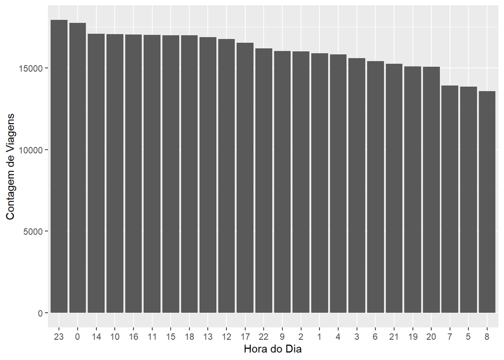

```r
contagem_hora %>%
  ggplot(aes(x = fct_reorder(hora, contagem, .desc = T), y = contagem))+
  geom_col()+
  labs(x = "Hora do Dia", y = "Contagem de Viagens")
```

3. Acrescente 1 coluna no banco informando se a corrida foi realizada pela “manhã” (entre 0h e 11h59), “tarde” (entre 12h e 17h59), e o restante como “noite”. (Para isso utilize a função ‘case_when’ do pacote ‘dplyr’).

```r
uber <- uber %>%
  mutate(turno = case_when(
    hour(data_hora) >= 0 &  hour(data_hora) < 12 ~ "manhã",
    hour(data_hora) >= 12 &  hour(data_hora) < 18 ~ "tarde",
    TRUE ~ "noite"
  ),
  turno = as.factor(turno)
  )


uber %>%
  select(turno, everything()) %>%
  head()
```

|  | turno | Origem | Destino | Tipo | Preço | Distância | Temperatura | Clima | Ano | Mes | Dia | Horario | data_hora | dia_semana |
| --- | --- | --- | --- | --- | --- | --- | --- | --- | --- | --- | --- | --- | --- | --- |
| 1 | noite | North End | West End | UberXL | 12.0 | 1.11 | 4.5 | Overcast | 2018 | 11 | 30 | 22:13:1 | 2018-11-30 22:13:01 | sexta-feira |
| 2 | manhã | North End | West End | Black | 16.0 | 1.11 | -6.5 | Clear | 2018 | 12 | 13 | 10:50:11 | 2018-12-13 10:50:11 | quinta-feira |
| 3 | noite | North End | West End | UberX | 7.5 | 1.11 | 0.5 | Mostly Cloudy | 2018 | 12 | 13 | 19:15:3 | 2018-12-13 19:15:03 | quinta-feira |
| 4 | noite | North End | West End | WAV | 7.5 | 1.11 | 5.2 | Light Rain | 2018 | 12 | 16 | 23:55:11 | 2018-12-16 23:55:11 | domingo |
| 5 | manhã | North End | West End | Black SUV | 26.0 | 1.11 | -0.4 | Overcast | 2018 | 12 | 14 | 0:40:7 | 2018-12-14 00:40:07 | sexta-feira |
| 6 | noite | North End | West End | UberPool | 5.5 | 1.11 | 6.4 | Mostly Cloudy | 2018 | 11 | 29 | 19:18:0 | 2018-11-29 19:18:00 | quinta-feira |

4. Faça um gráfico da contagem de viagens por periodo do dia (manhã,tarde e noite), ordenando do período com maior contagem para o período com menor contagem. Você esperava obter estes resultados após observar os resultados obtidos na questão 2b? (utilize o pacote forcats)

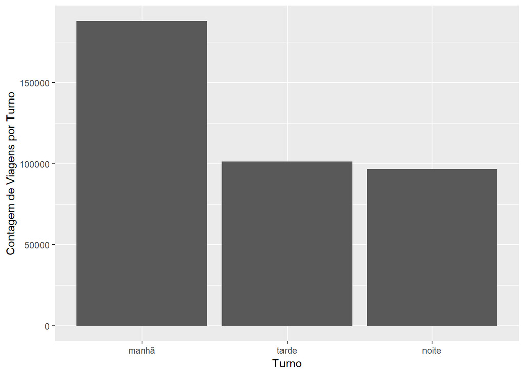

```r
uber %>%
  select(turno) %>%
  filter(!is.na(turno)) %>%
  group_by(turno) %>%
  summarise(contagem_turno = n()) %>%
  ggplot(aes(x = fct_reorder(turno, contagem_turno, .desc = T), y = contagem_turno))+
  geom_col()+
  labs(x = "Turno", y = "Contagem de Viagens por Turno")
```

Não é intuitivo pensar que pela manhã dará a maior quantidade de viagens, mas como é para considerar manhã desde 0 até 12, então a parte da manhã abrange uma maior intervalo, então é de se esperarar sim que tenha uma maior quantidade de viagens em comparação aos outros turnos que terão um intervalo menor.

5. Obtenha o preço e a distância média das viagens em cada turno do dia. Para estes dados, o turno do dia aparenta influenciar o preço médio e a distância média das viagens?

```r
uber %>%
  select(turno, Preço, Distância) %>%
  filter(!is.na(turno), !is.na(Preço), !is.na(Distância)) %>%
  group_by(turno) %>%
  mutate(Distância = as.numeric(Distância)) %>%
  summarise(media_preco = round(mean(Preço),2), media_distancia = round(mean(Distância),2))
```

| turno | media_preco | media_distancia |
| --- | --- | --- |
| manhã | 15.79 | 2.19 |
| noite | 15.82 | 2.20 |
| tarde | 15.78 | 2.19 |